# Projeto de Experimentos

Rafael Tenfen

Data de entrega: 11/06/2021

# Descrição da atividade

O objetivo desta atividade é aplicar a técnica de projeto de experimentos. A atividade é dividida em duas partes:

1. Definição de projetos de experimentos
2. ANOVA fatorial

Algumas recomendações:

- Se você não estiver habituado com R Markdown, acostume-se a processar com frequência o documento, usando o botão **Knit**. Isso permitirá que eventuais erros no documento ou no código R sejam identificados rapidamente, pouco depois de terem sido cometidos, o que facilitará sua correção. Na verdade, é uma boa ideia você fazer isso **agora**, para garantir que seu ambiente esteja configurado corretamente. Se você receber uma mensagem de erro do tipo *Error in library(foo)*, isso significa que o pacote `foo` não está instalado. Para instalar um pacote, execute o comando `install.packages("foo")` no Console, ou clique em *Tools* -> *Install Packages*.
- Após concluir a atividade, você deverá submeter no Moodle um arquivo ZIP contendo:
  - o arquivo fonte .Rmd;
  - a saída processada (PDF ou HTML) do arquivo .Rmd;
  - arquivos necessários para o processamento do .Rmd.

Uma forma simples de enviar uma submissão correta é exportar o seu projeto no RStudio Cloud e submeter o arquivo ZIP gerado.

# Configuração

Nesta atividade, nenhuma configuração é necessária por padrão, mas você pode usar o bloco abaixo para incluir o que julgar necessário.

```r
# insira seus comandos de configuração aqui
```

# Parte 1: Definição de Projetos de Experimentos

Nesta parte você irá considerar como aplicar o projeto de experimentos na análise de desempenho de um sistema ou aplicação de seu interesse.

1. Descreva brevemente o sistema.
2. Identifique uma ou mais métricas de desempenho que podem ser usadas como variável de resposta. O tempo de execução/resposta pode ser uma das métricas, mas não a única.
3. Identifique pelo menos 3 fatores que podem influenciar o desempenho do sistema. Para cada fator, descreva os níveis que você adotaria. Justifique brevemente a escolha dos fatores e dos níveis; não precisa discorrer sobre o assunto, apenas explicar porque você supõe que os fatores podem influenciar no desempenho e porque os níveis escolhidos são razoáveis.
4. Calcule o número de experimentos de um projeto fatorial completo usando os fatores e níveis descritos no item 3. Não se esqueça de considerar as replicações (defina quantas replicações seriam realizadas).
5. Partindo dos fatores e níveis definidos no item 3, monte um projeto $2^k$ para esse experimento, especificando quais fatores e níveis seriam usados no projeto. Calcule o número de experimentos do projeto, considerando o mesmo número de replicações do item 4.
6. Suponha que a análise dos resultados do projeto $2^k$ definido no item 5 revele que o fator com mais níveis proposto no item 3 não é estatisticamente significativo. Calcule quantos experimentos adicionais precisarão ser realizados para um projeto fatorial completo com os fatores significativos (considere replicações).

*Respostas aqui*

### 1

- Uma aplicação em C utilizando OpenMp, para verificação de números perfeitos.
- Números perfeitos são números inteiros positivos em que a soma de seus divisores positivos excluindo o próprio número, é igual ao seu valor. Exemplos de Números Perfeitos:
  - O número 6 é um número perfeito porque a soma de seus divisores são iguais ao número seis. (3 + 2 + 1) = 6.
  - 28: (14 + 7 + 4 + 2 + 1) = 28
  - 496
  - 8128
  - 33550336
  - 8589869056
  - 137438691328
  - 2305843008139952128
- Para verificar se o número é perfeito, foi utilizado “Brute force”: Dividir números antecessores um a um para verificar seus possíveis divisores, realizar a soma desses divisores e verificar se o resultado da soma é igual ao número, definindo assim o número como perfeito.
- Hardware utilizado nos testes ens5 8 CPU’s Intel(R) Xeon(R) CPU @ 3.50GHz 48 GB Memory

#### Open MP

A execução com OpenMP utilizou os seguintes alcances de números para verificação de números perfeitos: 0-100000, 0-300000 e 0-600000. Além das seguintes quantidades de threads: 1, 2, 4, 6 e 8, para cada alcance, e por fim foram testados os seguintes schedules: static, dynamic e guided para cada alcance e número de threads definidas. Todas as execuções foram testadas na mesma maquina: ens5.

#### MPI

A execução com o MPI utilizou os seguintes alcances de números para verificação de números perfeitos: 0-100000, 0-300000 e 0-600000. Além das seguintes quantidades de threads: 1, 2, 4, 8. Todas as execuções foram testadas na mesma maquina: ens5.

### 2

- “seconds”: Tempo de execução
- “memory”: Quantidade de memoria utilizada em kb

### 3

- “limit”: Alcance dos números a serem verificados se são perfeitos, como 100000, o sistema irá pesquisar todos os números de 1 até 100000 a fim de encontrar os números perfeitos nesse intervalo [100000, 300000, 600000]
- “threads”: Quantidade de threads utilizadas para realizar o paralelismo [1, 2, 4, 6, 8]
- “schedule”: Modo de paralelismo utilizado [“static”, “dynamic”, “guided”, “auto_open_mp”, “auto_mpi”]

### 4

- (“limit”) 3 x (“threads”) 5 x (“schedule”) 5 = 75 experimentos sem replicação, com 5 replicações teríamos 375 experimentos

### 5

- “limit”: [300000, 600000]
- “threads”: [2, 8]
- “schedule”: [“auto_open_mp”, “auto_mpi”]
- 8 experimentos sem replicaçao, com 5 replicaçoes teriamos 40 experimentos

### 6

- Tanto as threads quanto o schedule possuem 5 níveis, removendo apenas um deles, ficaria com (“limit”) 3 x (“threads” ou “schedule”) 5 = 15 experimentos sem replicação, com 5 replicações teríamos 75 experimentos, descontando 2^2=4 experimentos já realizados no item 5, ficam 11 experimentos sem replicação, e 55 experimentos com 5 replicações

# Parte 2: ANOVA Fatorial

Nesta parte da atividade você irá usar ANOVA fatorial para analisar os resultados de um conjunto de experimentos. Esses experimentos tinham por objetivo avaliar o impacto de processador e memória no tempo de execução de dois *benchmarks* A e B. Os fatores e níveis considerados foram:

| fator | níveis |
| --- | --- |
| CPU | AMD, Intel |
| no. de núcleos | 4, 8 |
| memória | 2 GB, 4 GB, 8 GB |

Foi usado um projeto de experimentos fatorial completo, com 5 replicações de cada experimento. Os dados coletados estão contidos no arquivo `doe-benchmarks.dat`, que contém as seguintes colunas:

- `benchmark`: qual o *benchmark* (A ou B);
- `cpu`: tipo de CPU;
- `cores`: quantidade de núcleos;
- `mem`: quantidade de memória;
- `tempo`: tempo de execução do *benchmark*.

Com base nesses dados, analise separadamente cada *benchmark*, seguindo os passos abaixo:

1. Analise graficamente como cada fator influencia o tempo de exemplo de execução.
2. Faça uma ANOVA fatorial, e identifique os fatores e interações estatisticamente significativos.
3. Faça a alocação de variação, descrevendo qual a porcentagem de variação explicada pelos fatores e interações significativos e pelos resíduos.
4. Use o teste de Tukey para verificar quais são as diferenças significativas entre os níveis dos fatores/interações significativos.
5. Faça o diagnóstico dos resíduos da ANOVA.
6. Verifique a premissa de homogeneidade de variâncias.
7. Descreva como os fatores significativos influenciam o tempo de execução. Leve em consideração as interações, se houver. (Sugestão: use gráficos de interação para visualização.)

**ATENÇÂO**: Os passos 1 a 7 deverão ser realizados duas vezes, uma para o *benchmark* A e outra para o *benchmark* B.

```r
benchmarks <- read.table("doe-benchmarks.dat", head=T)
str(benchmarks)
```

```
## 'data.frame':    120 obs. of  5 variables:
##  $ benchmark: Factor w/ 2 levels "A","B": 1 1 1 1 1 1 1 1 1 1 ...
##  $ cpu      : Factor w/ 2 levels "AMD","Intel": 1 2 1 2 1 2 1 2 1 2 ...
##  $ cores    : int  4 4 4 4 4 4 4 4 4 4 ...
##  $ mem      : Factor w/ 3 levels "2 GB","4 GB",..: 1 1 2 2 3 3 1 1 2 2 ...
##  $ tempo    : num  70.2 64.6 50.5 44.9 39.8 ...
```

```r
benchmarks.split <- split(benchmarks, factor(benchmarks$benchmark))
benchmarks.split$A$cores = as.factor(benchmarks.split$A$cores)
benchmarks.split$B$cores = as.factor(benchmarks.split$B$cores)
str(benchmarks.split$A)
```

```
## 'data.frame':    60 obs. of  5 variables:
##  $ benchmark: Factor w/ 2 levels "A","B": 1 1 1 1 1 1 1 1 1 1 ...
##  $ cpu      : Factor w/ 2 levels "AMD","Intel": 1 2 1 2 1 2 1 2 1 2 ...
##  $ cores    : Factor w/ 2 levels "4","8": 1 1 1 1 1 1 1 1 1 1 ...
##  $ mem      : Factor w/ 3 levels "2 GB","4 GB",..: 1 1 2 2 3 3 1 1 2 2 ...
##  $ tempo    : num  70.2 64.6 50.5 44.9 39.8 ...
```

```r
str(benchmarks.split$B)
```

```
## 'data.frame':    60 obs. of  5 variables:
##  $ benchmark: Factor w/ 2 levels "A","B": 2 2 2 2 2 2 2 2 2 2 ...
##  $ cpu      : Factor w/ 2 levels "AMD","Intel": 1 2 1 2 1 2 1 2 1 2 ...
##  $ cores    : Factor w/ 2 levels "4","8": 1 1 1 1 1 1 1 1 1 1 ...
##  $ mem      : Factor w/ 3 levels "2 GB","4 GB",..: 1 1 2 2 3 3 1 1 2 2 ...
##  $ tempo    : num  31 35.5 24.4 25.7 24.6 ...
```

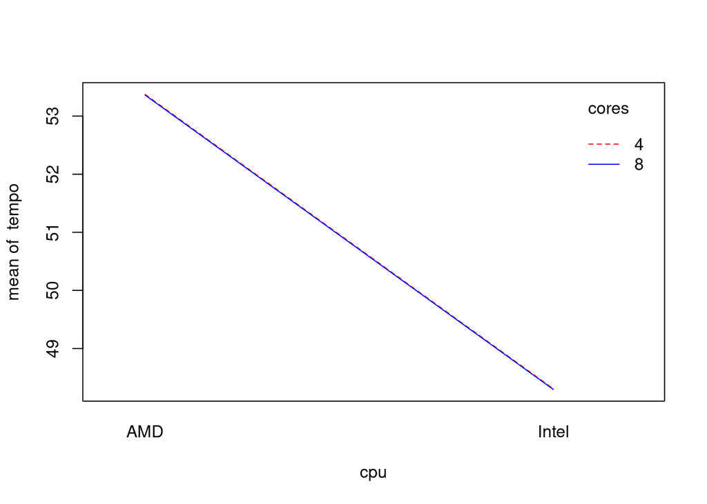

```r
with(benchmarks.split$A, interaction.plot(cpu, cores, tempo, col = c("red", "blue")))
```

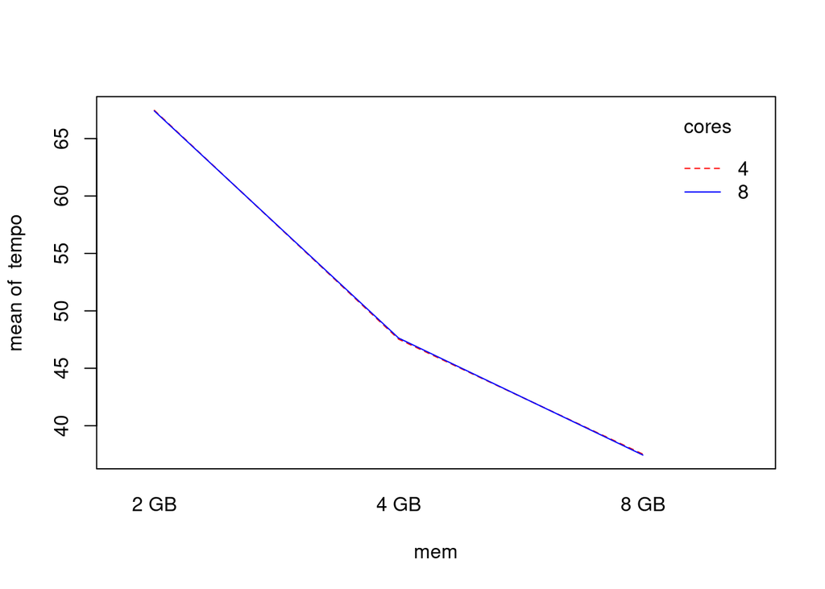

```r
with(benchmarks.split$A, interaction.plot(mem, cores, tempo, col = c("red", "blue")))
```

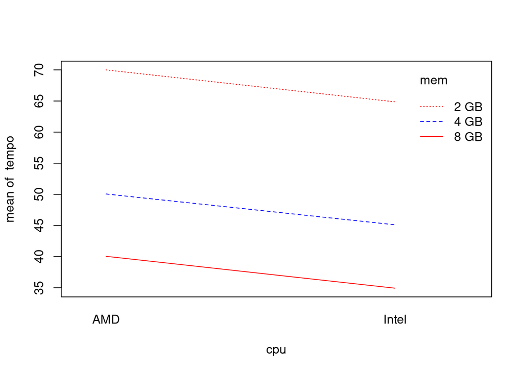

```r
with(benchmarks.split$A, interaction.plot(cpu, mem, tempo, col = c("red", "blue")))
```

```r
(benchmarks.split$A.aov = aov(tempo ~ cpu * cores * mem, benchmarks.split$A))
```

```
## Call:
##    aov(formula = tempo ~ cpu * cores * mem, data = benchmarks.split$A)
##
## Terms:
##                      cpu    cores      mem cpu:cores  cpu:mem cores:mem
## Sum of Squares   384.864    0.002 9283.118     0.000    0.098     0.083
## Deg. of Freedom        1        1        2         1        2         2
##                 cpu:cores:mem Residuals
## Sum of Squares          0.016     9.502
## Deg. of Freedom             2        48
##
## Residual standard error: 0.4449195
## Estimated effects may be unbalanced
```

```r
summary(benchmarks.split$A.aov)
```

```
##               Df Sum Sq Mean Sq   F value Pr(>F)
## cpu            1    385     385  1944.216 <2e-16 ***
## cores          1      0       0     0.010  0.922
## mem            2   9283    4642 23447.745 <2e-16 ***
## cpu:cores      1      0       0     0.000  0.995
## cpu:mem        2      0       0     0.248  0.781
## cores:mem      2      0       0     0.211  0.811
## cpu:cores:mem  2      0       0     0.041  0.959
## Residuals     48     10       0
## ---
## Signif. codes:  0 '***' 0.001 '**' 0.01 '*' 0.05 '.' 0.1 ' ' 1
```

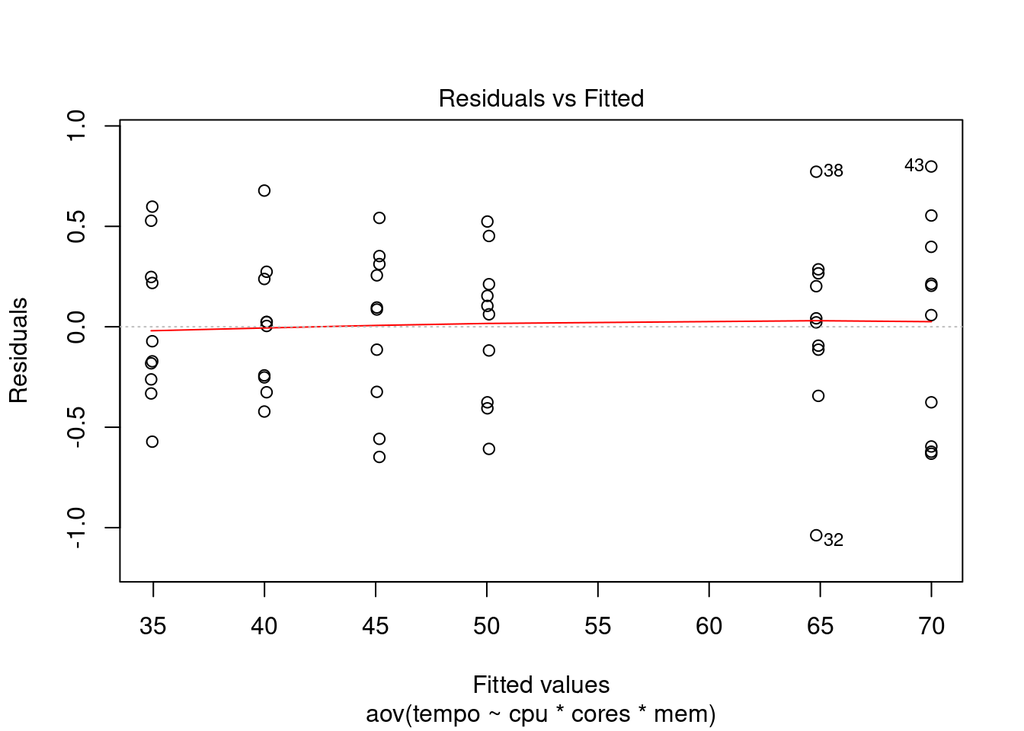

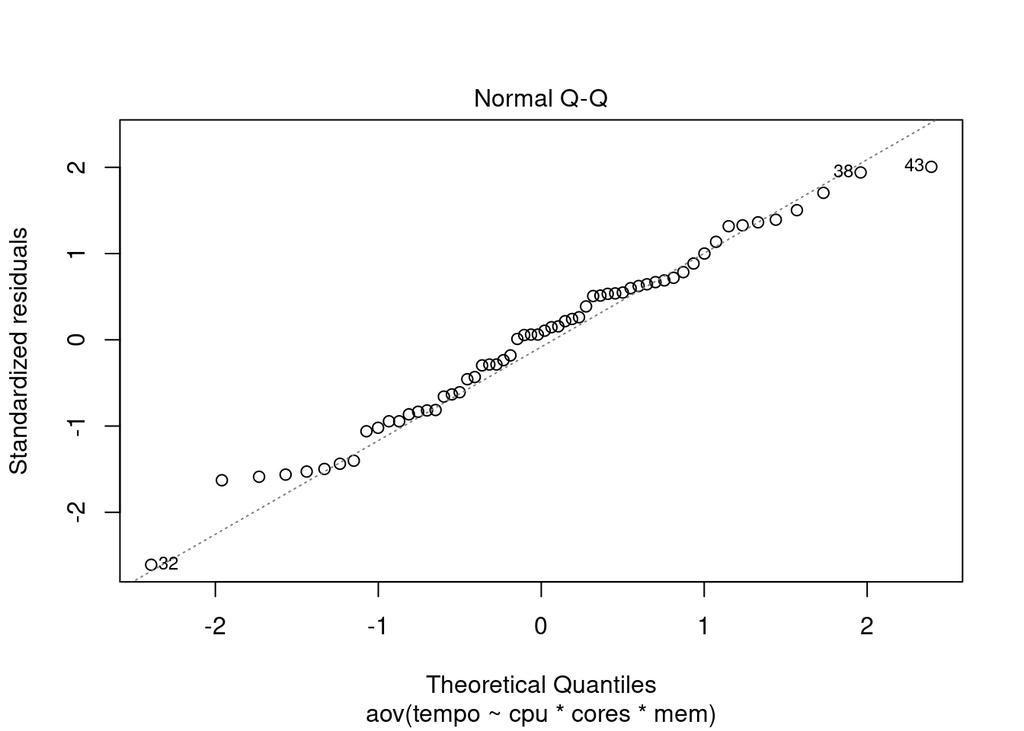

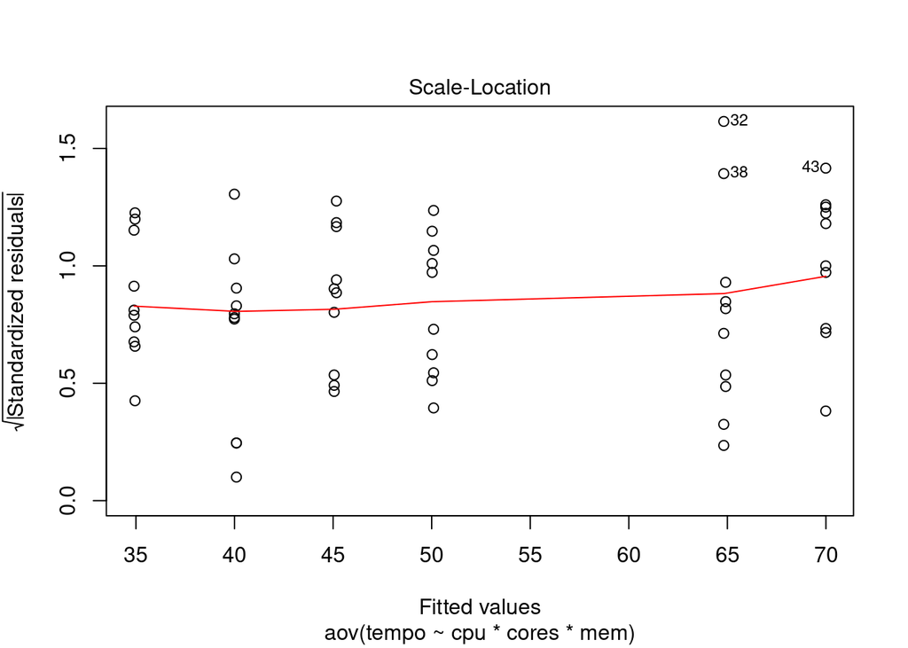

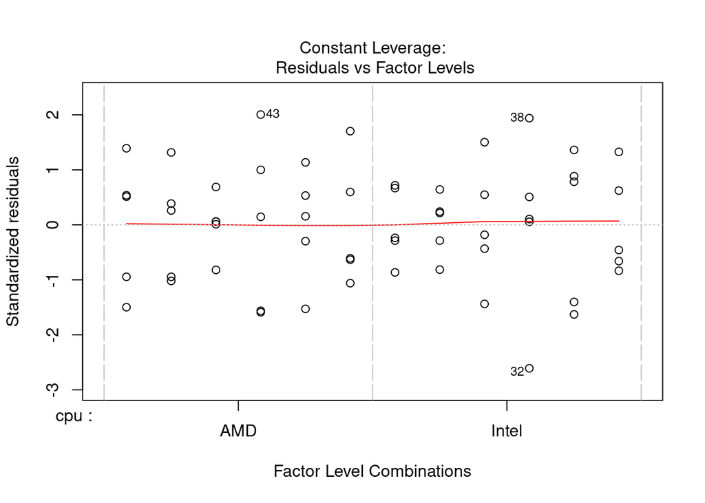

```r
plot(benchmarks.split$A.aov)
```

```r
(SS = anova(benchmarks.split$A.aov)['Sum Sq'])
```

```
##               Sum Sq
## cpu            384.9
## cores            0.0
## mem           9283.1
## cpu:cores        0.0
## cpu:mem          0.1
## cores:mem        0.1
## cpu:cores:mem    0.0
## Residuals        9.5
```

```r
SST = sum(SS)
(benchmarks.split$A.pv = round(100*SS/SST, 2))
```

```
##               Sum Sq
## cpu             3.98
## cores           0.00
## mem            95.92
## cpu:cores       0.00
## cpu:mem         0.00
## cores:mem       0.00
## cpu:cores:mem   0.00
## Residuals       0.10
```

```r
(benchmarks.split$A.flig = fligner.test(tempo ~ interaction(cpu, cores, mem), benchmarks.split$A))
```

```
##
##  Fligner-Killeen test of homogeneity of variances
##
## data:  tempo by interaction(cpu, cores, mem)
## Fligner-Killeen:med chi-squared = 6.5785, df = 11, p-value = 0.8321
```

```r
# p-value > alfa (assumindo 95% de nivel de confiança), então é válido


TukeyHSD(benchmarks.split$A.aov)
```

```
##   Tukey multiple comparisons of means
##     95% family-wise confidence level
##
## Fit: aov(formula = tempo ~ cpu * cores * mem, data = benchmarks.split$A)
##
## $cpu
##                diff      lwr       upr p adj
## Intel-AMD -5.065333 -5.29631 -4.834356     0
##
## $cores
##            diff        lwr       upr     p adj
## 8-4 -0.01133333 -0.2423105 0.2196438 0.9218225
##
## $mem
##               diff       lwr        upr p adj
## 4 GB-2 GB -19.8435 -20.18377 -19.503229     0
## 8 GB-2 GB -29.9445 -30.28477 -29.604229     0
## 8 GB-4 GB -10.1010 -10.44127  -9.760729     0
##
## $`cpu:cores`
##                        diff        lwr        upr     p adj
## Intel:4-AMD:4   -5.06600000 -5.4983709 -4.6336291 0.0000000
## AMD:8-AMD:4     -0.01200000 -0.4443709  0.4203709 0.9998533
## Intel:8-AMD:4   -5.07666667 -5.5090375 -4.6442958 0.0000000
## AMD:8-Intel:4    5.05400000  4.6216291  5.4863709 0.0000000
## Intel:8-Intel:4 -0.01066667 -0.4430375  0.4217042 0.9998969
## Intel:8-AMD:8   -5.06466667 -5.4970375 -4.6322958 0.0000000
##
## $`cpu:mem`
##                          diff        lwr        upr p adj
## Intel:2 GB-AMD:2 GB    -5.128  -5.718534  -4.537466     0
## AMD:4 GB-AMD:2 GB     -19.932 -20.522534 -19.341466     0
## Intel:4 GB-AMD:2 GB   -24.883 -25.473534 -24.292466     0
## AMD:8 GB-AMD:2 GB     -29.950 -30.540534 -29.359466     0
## Intel:8 GB-AMD:2 GB   -35.067 -35.657534 -34.476466     0
## AMD:4 GB-Intel:2 GB   -14.804 -15.394534 -14.213466     0
## Intel:4 GB-Intel:2 GB -19.755 -20.345534 -19.164466     0
## AMD:8 GB-Intel:2 GB   -24.822 -25.412534 -24.231466     0
## Intel:8 GB-Intel:2 GB -29.939 -30.529534 -29.348466     0
## Intel:4 GB-AMD:4 GB    -4.951  -5.541534  -4.360466     0
```

[output cut: 77 more lines]

```
## Intel:8:4 GB-AMD:8:4 GB    -4.930  -5.8962238  -3.9637762 0.0000000
## AMD:4:8 GB-AMD:8:4 GB     -10.002 -10.9682238  -9.0357762 0.0000000
## Intel:4:8 GB-AMD:8:4 GB   -15.146 -16.1122238 -14.1797762 0.0000000
## AMD:8:8 GB-AMD:8:4 GB     -10.106 -11.0722238  -9.1397762 0.0000000
## Intel:8:8 GB-AMD:8:4 GB   -15.196 -16.1622238 -14.2297762 0.0000000
## AMD:4:8 GB-Intel:8:4 GB    -5.072  -6.0382238  -4.1057762 0.0000000
## Intel:4:8 GB-Intel:8:4 GB -10.216 -11.1822238  -9.2497762 0.0000000
## AMD:8:8 GB-Intel:8:4 GB    -5.176  -6.1422238  -4.2097762 0.0000000
## Intel:8:8 GB-Intel:8:4 GB -10.266 -11.2322238  -9.2997762 0.0000000
## Intel:4:8 GB-AMD:4:8 GB    -5.144  -6.1102238  -4.1777762 0.0000000
## AMD:8:8 GB-AMD:4:8 GB      -0.104  -1.0702238   0.8622238 0.9999998
## Intel:8:8 GB-AMD:4:8 GB    -5.194  -6.1602238  -4.2277762 0.0000000
## AMD:8:8 GB-Intel:4:8 GB     5.040   4.0737762   6.0062238 0.0000000
## Intel:8:8 GB-Intel:4:8 GB  -0.050  -1.0162238   0.9162238 1.0000000
## Intel:8:8 GB-AMD:8:8 GB    -5.090  -6.0562238  -4.1237762 0.0000000
```

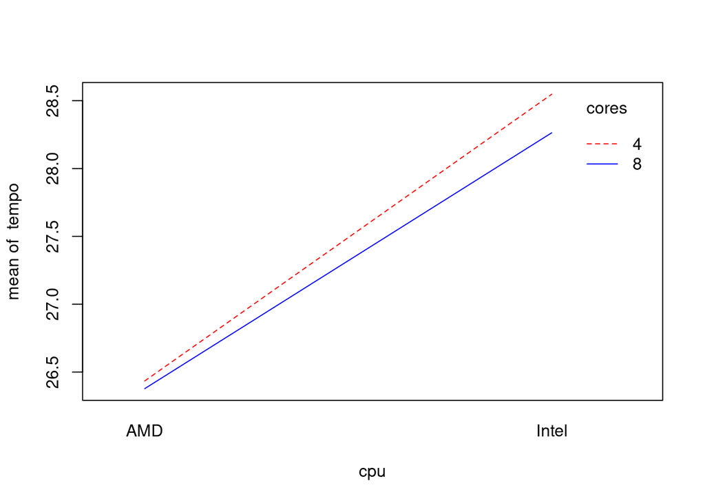

```r
# TESTE BENCHMARK B

with(benchmarks.split$B, interaction.plot(cpu, cores, tempo, col = c("red", "blue")))
```

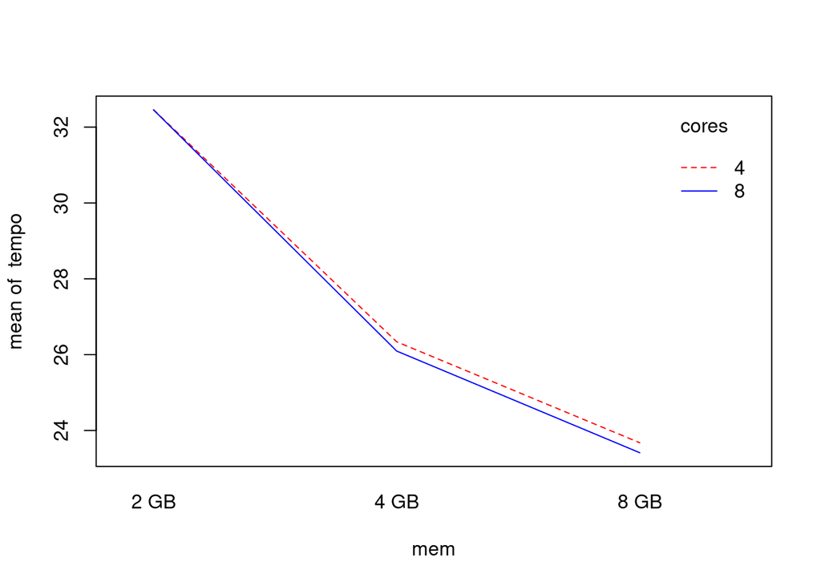

```r
with(benchmarks.split$B, interaction.plot(mem, cores, tempo, col = c("red", "blue")))
```

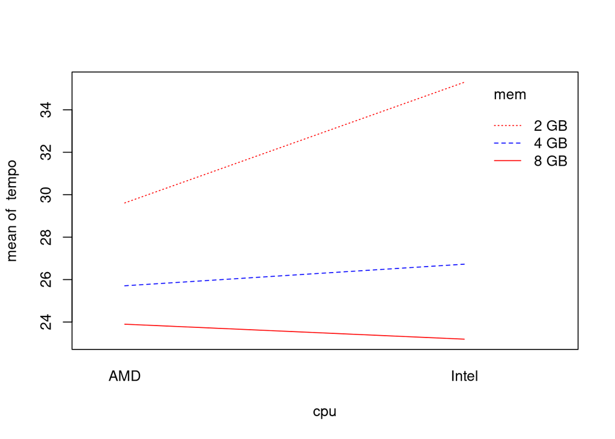

```r
with(benchmarks.split$B, interaction.plot(cpu, mem, tempo, col = c("red", "blue")))
```

```r
(benchmarks.split$B.aov = aov(tempo ~ cpu * cores * mem, benchmarks.split$B))
```

```
## Call:
##    aov(formula = tempo ~ cpu * cores * mem, data = benchmarks.split$B)
##
## Terms:
##                      cpu    cores      mem cpu:cores  cpu:mem cores:mem
## Sum of Squares   59.9400   0.4352 836.0669    0.1938 109.3127    0.2108
## Deg. of Freedom        1        1        2         1        2         2
##                 cpu:cores:mem Residuals
## Sum of Squares         0.5559   48.0400
## Deg. of Freedom             2        48
##
## Residual standard error: 1.000416
## Estimated effects may be unbalanced
```

```r
summary(benchmarks.split$B.aov)
```

```
##               Df Sum Sq Mean Sq F value   Pr(>F)
## cpu            1   59.9    59.9  59.890 5.47e-10 ***
## cores          1    0.4     0.4   0.435    0.513
## mem            2  836.1   418.0 417.686  < 2e-16 ***
## cpu:cores      1    0.2     0.2   0.194    0.662
## cpu:mem        2  109.3    54.7  54.611 4.30e-13 ***
## cores:mem      2    0.2     0.1   0.105    0.900
## cpu:cores:mem  2    0.6     0.3   0.278    0.759
## Residuals     48   48.0     1.0
## ---
## Signif. codes:  0 '***' 0.001 '**' 0.01 '*' 0.05 '.' 0.1 ' ' 1
```

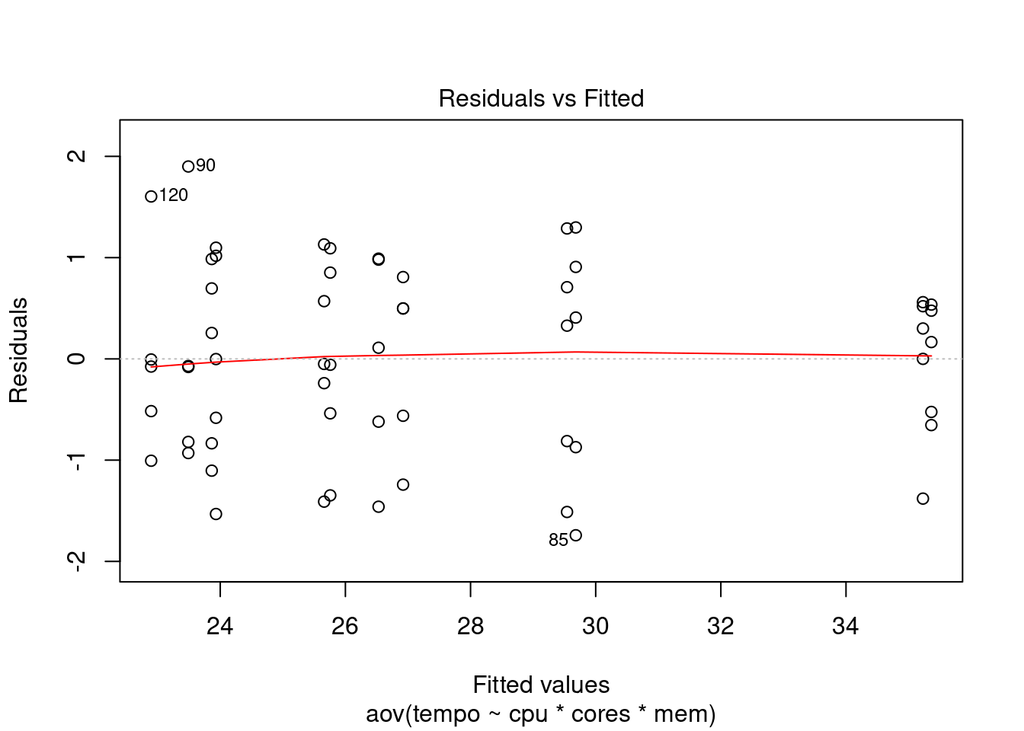

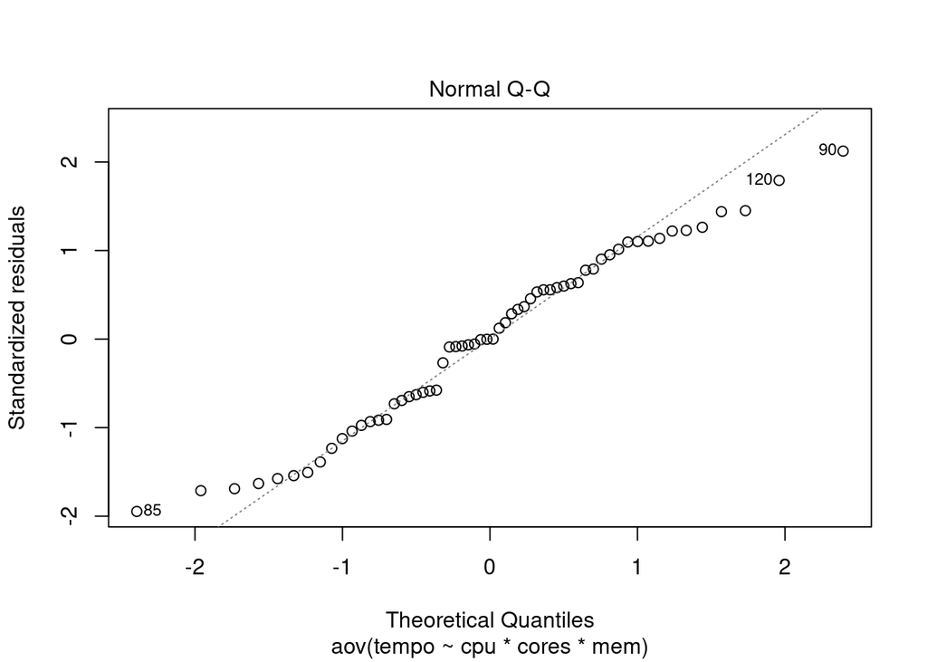

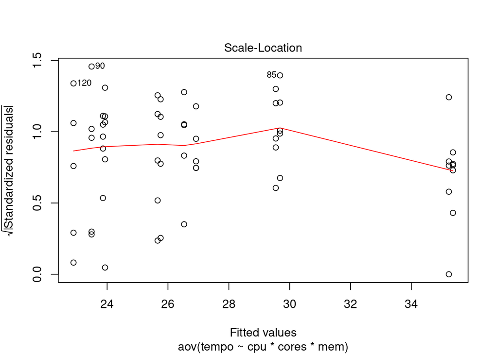

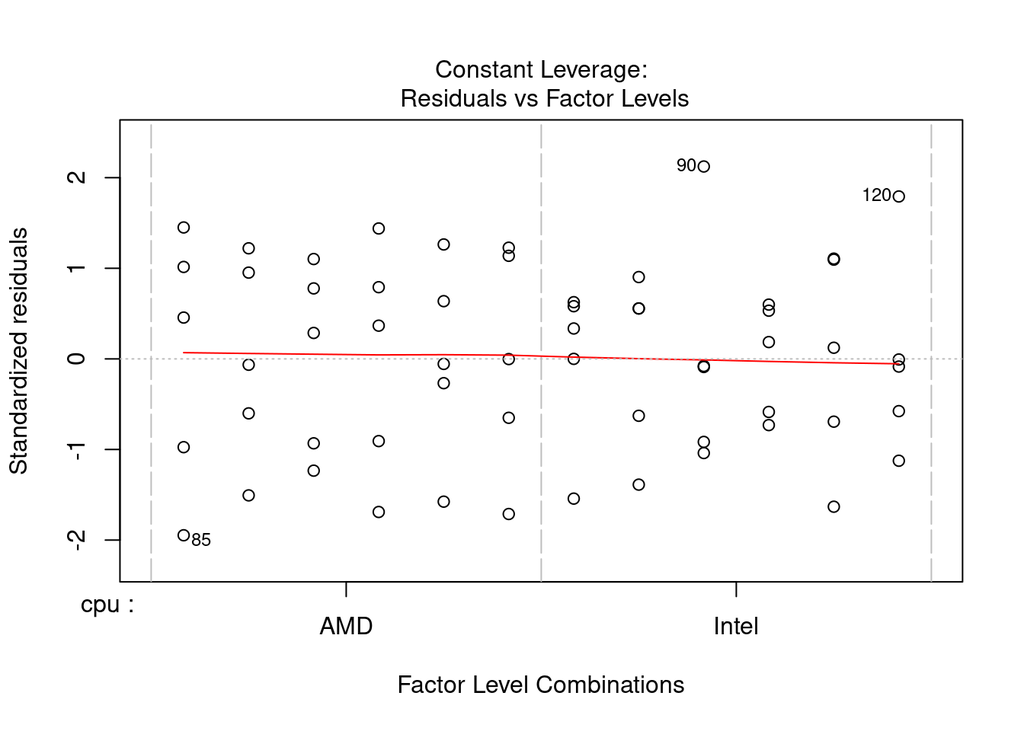

```r
plot(benchmarks.split$B.aov)
```

```r
(SS = anova(benchmarks.split$B.aov)['Sum Sq'])
```

```
##               Sum Sq
## cpu            59.94
## cores           0.44
## mem           836.07
## cpu:cores       0.19
## cpu:mem       109.31
## cores:mem       0.21
## cpu:cores:mem   0.56
## Residuals      48.04
```

```r
SST = sum(SS)
(benchmarks.split$B.pv = round(100*SS/SST, 2))
```

```
##               Sum Sq
## cpu             5.68
## cores           0.04
## mem            79.27
## cpu:cores       0.02
## cpu:mem        10.36
## cores:mem       0.02
## cpu:cores:mem   0.05
## Residuals       4.55
```

```r
(benchmarks.split$B.flig = fligner.test(tempo ~ interaction(cpu, cores, mem), benchmarks.split$B))
```

```
##
##  Fligner-Killeen test of homogeneity of variances
##
## data:  tempo by interaction(cpu, cores, mem)
## Fligner-Killeen:med chi-squared = 3.7271, df = 11, p-value = 0.9772
```

```r
# p-value > alfa (assumindo 95% de nivel de confiança), então é válido


TukeyHSD(benchmarks.split$B.aov)
```

```
##   Tukey multiple comparisons of means
##     95% family-wise confidence level
##
## Fit: aov(formula = tempo ~ cpu * cores * mem, data = benchmarks.split$B)
##
## $cpu
##            diff     lwr     upr p adj
## Intel-AMD 1.999 1.47964 2.51836     0
##
## $cores
##           diff       lwr       upr     p adj
## 8-4 -0.1703333 -0.689693 0.3490264 0.5127752
##
## $mem
##             diff       lwr       upr p adj
## 4 GB-2 GB -6.237 -7.002111 -5.471889     0
## 8 GB-2 GB -8.909 -9.674111 -8.143889     0
## 8 GB-4 GB -2.672 -3.437111 -1.906889     0
##
## $`cpu:cores`
##                        diff        lwr        upr     p adj
## Intel:4-AMD:4    2.11266667  1.1404665  3.0848669 0.0000032
## AMD:8-AMD:4     -0.05666667 -1.0288669  0.9155335 0.9986514
## Intel:8-AMD:4    1.82866667  0.8564665  2.8008669 0.0000458
## AMD:8-Intel:4   -2.16933333 -3.1415335 -1.1971331 0.0000018
## Intel:8-Intel:4 -0.28400000 -1.2562002  0.6882002 0.8642730
## Intel:8-AMD:8    1.88533333  0.9131331  2.8575335 0.0000270
##
## $`cpu:mem`
##                          diff         lwr         upr     p adj
## Intel:2 GB-AMD:2 GB     5.685   4.3571647   7.0128353 0.0000000
## AMD:4 GB-AMD:2 GB      -3.903  -5.2308353  -2.5751647 0.0000000
## Intel:4 GB-AMD:2 GB    -2.886  -4.2138353  -1.5581647 0.0000007
## AMD:8 GB-AMD:2 GB      -5.714  -7.0418353  -4.3861647 0.0000000
## Intel:8 GB-AMD:2 GB    -6.419  -7.7468353  -5.0911647 0.0000000
## AMD:4 GB-Intel:2 GB    -9.588 -10.9158353  -8.2601647 0.0000000
## Intel:4 GB-Intel:2 GB  -8.571  -9.8988353  -7.2431647 0.0000000
## AMD:8 GB-Intel:2 GB   -11.399 -12.7268353 -10.0711647 0.0000000
## Intel:8 GB-Intel:2 GB -12.104 -13.4318353 -10.7761647 0.0000000
## Intel:4 GB-AMD:4 GB     1.017  -0.3108353   2.3448353 0.2250650
```

[output cut: 77 more lines]

```
## Intel:8:4 GB-AMD:8:4 GB     0.870  -1.302586   3.042586139 0.9628686
## AMD:4:8 GB-AMD:8:4 GB      -1.796  -3.968586   0.376586139 0.1968653
## Intel:4:8 GB-AMD:8:4 GB    -2.170  -4.342586   0.002586139 0.0505255
## AMD:8:8 GB-AMD:8:4 GB      -1.728  -3.900586   0.444586139 0.2428830
## Intel:8:8 GB-AMD:8:4 GB    -2.764  -4.936586  -0.591413861 0.0034685
## AMD:4:8 GB-Intel:8:4 GB    -2.666  -4.838586  -0.493413861 0.0055732
## Intel:4:8 GB-Intel:8:4 GB  -3.040  -5.212586  -0.867413861 0.0008680
## AMD:8:8 GB-Intel:8:4 GB    -2.598  -4.770586  -0.425413861 0.0076956
## Intel:8:8 GB-Intel:8:4 GB  -3.634  -5.806586  -1.461413861 0.0000371
## Intel:4:8 GB-AMD:4:8 GB    -0.374  -2.546586   1.798586139 0.9999797
## AMD:8:8 GB-AMD:4:8 GB       0.068  -2.104586   2.240586139 1.0000000
## Intel:8:8 GB-AMD:4:8 GB    -0.968  -3.140586   1.204586139 0.9244740
## AMD:8:8 GB-Intel:4:8 GB     0.442  -1.730586   2.614586139 0.9998926
## Intel:8:8 GB-Intel:4:8 GB  -0.594  -2.766586   1.578586139 0.9982765
## Intel:8:8 GB-AMD:8:8 GB    -1.036  -3.208586   1.136586139 0.8862082
```